# BCB546_COURSE_PYTHON_ASSIGNEMENT

# Randy_Python_Assignment

Assignment: Complete Dr. X's script in a Jupyter notebook.

1. Document Dr. X's function with comments and with markdown test.
2. Write a function that translates a string of nucleotides to amino acids.
3. Write an alternative translation function.
4. Write a funciton that calculates the molecular weight of each 3 amino acid sequence.
5. Write a functio that computes the GC-content of each DNA sequence.
6. Add two new columns to the penguin DataFrame: (1) molecular weight and (2) GC content.
7. Call your functions from step 3 (or step 2) and step 4 and fill in the new columns in the DataFrame.
8. Plot a bar-chart of adult body mass per species. In your description of the graph, provide text that answers these questions: a. What is the smallest penguin species? b. What is the geographical range of this species?
9. Plot a graph that shows the molecular weight as a function of GC content.
10. Write the entire DataFrame to a new CSV file that includes your new columns.
11. BONUS: What other visualizations, functions or tasks would you do with this dataset? Add something interesting for fun. (0.5 additional points if your total score is < 15).

```python
# install all necessary packages including Biopython and import the following;

from Bio import SeqIO
from Bio.Data import CodonTable
import pandas as pd
from Bio.Seq import Seq
from Bio.SeqUtils.ProtParam import ProteinAnalysis
import numpy as np
import pandas as pd
import seaborn as sns # package willl be used to create interactive plots
import matplotlib.pyplot as plt

# Set default DPI for all plots
plt.rcParams['figure.figsize'] = [12, 5]
plt.rcParams['figure.dpi'] = 400; # For screen display
plt.rcParams['savefig.dpi'] = 400;  # For saving files
```

## Function 1

Dr. X: This function gets sequences.

`get_sequences_from_file(fasta_fn)`

This function takes a .fasta file name as the input and returns a dictornary with species names as keys and sequences as the value. It assumes that the species name is two words after the identifier.

```python
def get_sequences_from_file(fasta_fn): # this will be the function that we run to create a directory from our fasta file
    sequence_data_dict = {} #creates a directory
    for record in SeqIO.parse(fasta_fn, "fasta"): #uses SeqIO to parse fasta file and extract sequence data
        description = record.description.split() #splits the record.decription string value and give variable name "discription"
        species_name = description[1] + " " + description[2] #assumes that the species name is formated in two words seperated by a space
        sequence_data_dict[species_name] = record.seq #species name is a key and the sequence is the value
    return(sequence_data_dict) #returns the completed directory
```

```python
# My_script for the function above;

def get_sequences_from_file(fasta_fn):
    sequence_data_dict = {}
    for record in SeqIO.parse("penguins_cytb.fasta","fasta"):
        description = record.description.split()
        species_name = description[1] + " " + description[2]
        sequence_data_dict[species_name] = record.seq
    return(sequence_data_dict)
```

## Function 2

Function that translates sequences.

`translate_function(nucleotides)`

This is the function that will be used to translate a string of nucleotides to amino acids.

**Resources Used**

https://www.digitalocean.com/community/tutorials/how-to-use-break-continue-and-pass-statements-when-working-with-loops-in-python-3

https://www.codecademy.com/learn/introduction-to-python-dvp/modules/python-syntax-dvp/cheatsheet

```python
# psuedo-code provided by Dr. X
def translate_function(string_nucleotides):
     mito_table = CodonTable.unambiguous_dna_by_name["Vertebrate Mitochondrial"] # this should work using BioPython (be sure to check what this returns)
     for-loop through every 3rd position in string_nucleotides to get the codon using range subsets
         # IMPORTANT: if the sequence has a stop codon at the end, you should leave it off
         # this is how you can retrieve the amino acid: mito_table.forward_table[codon]
         add the aa to aa_seq_string
     return(aa_seq_string)
```

```python
# Create the mitochondria table variable for the codon table and print if out;
mito_table = CodonTable.unambiguous_dna_by_name["Vertebrate Mitochondrial"]
print(mito_table)
```

```
Table 2 Vertebrate Mitochondrial, SGC1

  |  T      |  C      |  A      |  G      |
--+---------+---------+---------+---------+--
T | TTT F   | TCT S   | TAT Y   | TGT C   | T
T | TTC F   | TCC S   | TAC Y   | TGC C   | C
T | TTA L   | TCA S   | TAA Stop| TGA W   | A
T | TTG L   | TCG S   | TAG Stop| TGG W   | G
--+---------+---------+---------+---------+--
C | CTT L   | CCT P   | CAT H   | CGT R   | T
C | CTC L   | CCC P   | CAC H   | CGC R   | C
C | CTA L   | CCA P   | CAA Q   | CGA R   | A
C | CTG L   | CCG P   | CAG Q   | CGG R   | G
--+---------+---------+---------+---------+--
A | ATT I(s)| ACT T   | AAT N   | AGT S   | T
A | ATC I(s)| ACC T   | AAC N   | AGC S   | C
A | ATA M(s)| ACA T   | AAA K   | AGA Stop| A
A | ATG M(s)| ACG T   | AAG K   | AGG Stop| G
--+---------+---------+---------+---------+--
G | GTT V   | GCT A   | GAT D   | GGT G   | T
G | GTC V   | GCC A   | GAC D   | GGC G   | C
G | GTA V   | GCA A   | GAA E   | GGA G   | A
G | GTG V(s)| GCG A   | GAG E   | GGG G   | G
--+---------+---------+---------+---------+--
```

```python
# make empty string to store translated sequence
aa_seq_string = []

# make empty string to store codons
codons = []

# loop through every 3rd position in string_nucleotides (input) to get codon
for i in range (0, len(string_nucleotides), 3):

    #gets a codon length of 3 and adds it to our 'codons' list
    codon= string_nucleotides[i,i+3]


    #check for stop codons, and terminate for loop at stop codon
    if codon in ["TAA", "TAG", "AGA", "AGG"]:
        break
    codons.append(codon) # adds our codon to the 'codons' list if it is not a stop codon

    #retrieve amino acid from codon sequence
    mito_table.forward_table[codon]

    #adds amino acids to 'aa_seq_string' and will concatonate
    aa_seq_string += mito_table.forward_table[codon]

print(aa_seq_string) # will print our amino acids sequence
print(codons) # will print our codons
```

```python
# My_script for the function above;

def translate_function(nucleotides):
    codons = []
    aa_seq_string = ""

    for i in range (0, len(nucleotides), 3):
        codon = nucleotides[i:i+3]
        if codon in ["TAA", "TAG", "AGA", "AGG"]:
            break
        codons.append(codon)

        aa_seq_string += mito_table.forward_table[codon]
    return aa_seq_string
```

```python
#example of funcitonal code

nucleotides = "TGTGCGACCTAA"
codons = []
aa_seq_string = ""

for i in range (0, len(nucleotides), 3):
    codon = nucleotides[i:i+3]
    if codon in ["TAA", "TAG", "AGA", "AGG"]:
        break
    codons.append(codon)
    aa_seq_string += mito_table.forward_table[codon]

print(aa_seq_string)
print(codons)
```

```
CAT
['TGT', 'GCG', 'ACC']
```

```python
#test run

translate_function("TGTGCGACCTAA")
```

```
'CAT'
```

## Fucntion 3

Alternative function for translation.

`translate_BioSeq(nucleotides)`

Using an avaible function for BioPythong library, will need install Bio.Seq using the following:

`from Bio.Seq import Seq`

**Resources Used**

https://biopython.org/docs/1.78/api/Bio.Seq.html

```python
#in BioPython Bio.Seq module, there is a translate function that translates nucleotide strings to amino acid strings
#input is a string of nucleotides

Seq.translate(nucleotides, table=2, to_stop=True)

#table 2 refers to the codon table for "Vertibrate Mitochoindrial"
# to_stop=True is fereing to stopping at stop codons

return seq_string #returns the amino acid string as the output
```

```python
# My_script for the function above;

def translate_BioSeq(nucleotides):
    seq_string = Seq.translate(nucleotides, table=2, to_stop=True)
    return seq_string
```

```python
# Example of use and test run

translate_BioSeq("TGTGCGACCTAA")
```

```
'CAT'
```

## Function 4

Write a funciton that calculates the molecular weight of amino acid sequences.

`compute_molecular_weight(aa_seq)`

Uses the module below:

`from Bio.SeqUtils.ProtParam import ProteinAnalysis`

**Resources Used**

https://biopython.org/wiki/ProtParam

```python
# psuedo code from Dr.X

# you should import the following before defining your function:
from Bio.SeqUtils.ProtParam import ProteinAnalysis

def compute_molecular_weight(aa_seq):
     # I think the ProtParam functions may require aa_seq to be a string.
     # It may not work if the amino acid sequence has stop codons.
   run the ProteinAnalysis() function on aa_seq
return the molecular weight
```

```python
# testing output of ProteinAnalysis

temp_aa = ProteinAnalysis("CAT")
print(temp_aa)
```

```
<Bio.SeqUtils.ProtParam.ProteinAnalysis object at 0x000001FAFC6F5B90>
```

```python
# testing molecular.weight output

molecular_weight = temp_aa.molecular_weight()
print(molecular_weight)
```

```
293.34
```

```python
# uses ProteinAnalysis on an amino acids string (makes sure it is a protein) and stores the variable in 'temp_aa'
temp_aa = ProteinAnalysis(aa_seq)

# uses molecular.weight function to find the molucular weight of the vcariable stored in 'temp_aa' and places it in 'molecular_weight'
 molecular_weight = temp_aa.molecular_weight()
    return molecular_weight #returns the molecular weight
```

```python
# My_script for the function above;

def compute_molecular_weight(aa_seq):
    temp_aa = ProteinAnalysis(aa_seq)
    molecular_weight = temp_aa.molecular_weight()
    return molecular_weight
```

```python
#testing function

compute_molecular_weight("CAT")
```

```
293.34
```

## Function 5

The following is a function for calculating the GC content in a DNA sequence.

`gc_content(nucleotides)`

**Resources Used**

https://www.labxchange.org/library/items/lb:LabXchange:a6c1b925:video:1?source=%2Flibrary%2Fclusters%2Flx-cluster%3Aabe-italiano

```python
# test script

sequence = ("TGTGCGACCTAA")

gc_content = (sequence.count("C") + sequence.count("G")) / len(sequence) * 100

print(gc_content)
```

```
50.0
```

```python
# setting up our nucleotides to a variable
sequence = (nucleotides)

#GC_content is the total count of "C" and "G" within our sequence, divided by the length of our sequence, times 100 for percentage
gc_content = (sequence.count("C") + sequence.count("G")) / len(sequence) * 100

#return/print our value for gc_content
   return gc_content
```

```python
#My_script for the function above;

def compute_gc_content(nucleotides):
    sequence = (nucleotides)
    gc_content = (sequence.count("C") + sequence.count("G")) / len(sequence) * 100
    return gc_content
```

```python
# Testing fucntion

compute_gc_content("TGTGCGACCTAA")
```

```
50.0
```

## Main

```python
cytb_seqs = get_sequences_from_file("penguins_cytb.fasta")
penguins_df = pd.read_csv("penguins_mass.csv") # Includes only data for body mass
species_list = list(penguins_df.species)
print(cytb_seqs)
```

[output not shown]

```python
print(penguins_df)
```

```
                    species   mass
0      Aptenodytes forsteri  28.00
1   Aptenodytes patagonicus  13.40
2       Eudyptes chrysocome   2.80
3     Eudyptes chrysolophus   4.50
4         Eudyptes sclateri   4.25
5           Eudyptula minor   1.60
6        Pygoscelis adeliae   4.60
7     Pygoscelis antarctica   4.10
8          Pygoscelis papua   6.10
9       Spheniscus demersus   3.20
10     Spheniscus humboldti   4.75
11  Spheniscus magellanicus   3.40
```

```python
print(species_list)
```

```
['Aptenodytes forsteri', 'Aptenodytes patagonicus', 'Eudyptes chrysocome', 'Eudyptes chrysolophus', 'Eudyptes sclateri', 'Eudyptula minor', 'Pygoscelis adeliae', 'Pygoscelis antarctica', 'Pygoscelis papua', 'Spheniscus demersus', 'Spheniscus humboldti', 'Spheniscus magellanicus']
```

## Function 6

Uses the following module:

`import numpy as np`

1. Add two new columns to the penquin DataFrame: (1) molecular weight and (2) GC content.
2. Set the value to 'NaN' to indicate that these cells are currently empty.

```python
# add moleculare_weight as a column to 'penguins_df' and set all values to NaN
penguins_df["molecular_weight"] = np.nan

# add GC_content as a colum to 'penguins_df' and sett all values to NaN
penguins_df["GC_content"] = np.nan

print(penguins_df)
```

```
                    species   mass  molecular_weight  GC_content
0      Aptenodytes forsteri  28.00               NaN         NaN
1   Aptenodytes patagonicus  13.40               NaN         NaN
2       Eudyptes chrysocome   2.80               NaN         NaN
3     Eudyptes chrysolophus   4.50               NaN         NaN
4         Eudyptes sclateri   4.25               NaN         NaN
5           Eudyptula minor   1.60               NaN         NaN
6        Pygoscelis adeliae   4.60               NaN         NaN
7     Pygoscelis antarctica   4.10               NaN         NaN
8          Pygoscelis papua   6.10               NaN         NaN
9       Spheniscus demersus   3.20               NaN         NaN
10     Spheniscus humboldti   4.75               NaN         NaN
11  Spheniscus magellanicus   3.40               NaN         NaN
```

## Function 7

Write a for-loop that translates each sequence and also gets molecular weight and computes the GC content of each translated sequence and adds those data to 'penguins_df'.

```python
# from Dr. X:

for key, value in cytb_seqs.items():
     aa_seq = nuc2aa_translate_function(value) # whichever function you prefer of #2 or #3
     #get the molecular weight of aa_seq
     #get the GC content of the DNA sequence
     #fill in empty cells in DF that you created above
```

```python
# initialize empty lists for storage of molecule weight and GC content
mol_wt_list = []
gc_list = []

# key referece to species and value refers to sequence valuse assigned to that species
for key, value in cytb_seqs.items ():

    # translate sequence using function 3
    aa_seq = translate_BioSeq(value)

    # compute molecular weight using function 4 ; aa_seq needs to be a string
    molecular_weight = compute_molecular_weight(str(aa_seq))

    # compute GC content using function 5
    gc_content = compute_gc_content(value)

    # append our mol_wt_list and gc_list
    mol_wt_list.append(molecular_weight)
    gc_list.append(gc_content)

# update values in our 'penguins_df'
penguins_df["molecular_weight"] = mol_wt_list
penguins_df["GC_content"] = gc_list

print(penguins_df)
```

[output not shown]

```python
# My_script for the function above;

mol_wt_list = []
gc_list = []

for key, value in cytb_seqs.items ():
    aa_seq = translate_BioSeq(value)
    molecular_weight = compute_molecular_weight(str(aa_seq))
    gc_content = compute_gc_content(value)
    mol_wt_list.append(molecular_weight)
    gc_list.append(gc_content)

penguins_df["molecular_weight"] = mol_wt_list
penguins_df["GC_content"] = gc_list

print(penguins_df)
```

```
                    species   mass  molecular_weight  GC_content
0      Aptenodytes forsteri  28.00        42459.6021   48.381452
1   Aptenodytes patagonicus  13.40        42563.7067   49.693788
2       Eudyptes chrysocome   2.80        42475.5753   51.181102
3     Eudyptes chrysolophus   4.50        42445.5493   50.918635
4         Eudyptes sclateri   4.25        42475.5753   50.831146
5           Eudyptula minor   1.60        42491.6408   49.256343
6        Pygoscelis adeliae   4.60        42458.6140   49.081365
7     Pygoscelis antarctica   4.10        42404.5423   47.769029
8          Pygoscelis papua   6.10        42595.8759   47.156605
9       Spheniscus demersus   3.20        42431.5490   48.293963
10     Spheniscus humboldti   4.75        42399.5520   49.256343
11  Spheniscus magellanicus   3.40        42459.6021   48.206474
```

## Function 8

Plot a bar-chart of the mass with the x-axes labeled with species names.

**Q1** What is the smallest penguin species?

**A1** Eudyptula minor

**Q2** What is the geographical range of this species?

**A2** They are found throughout southern Austrila and New Zealand

**Resource Used**

https://www.marinebio.org/species/little-blue-penguins/eudyptula-minor/#:~:text=World%20Range%20%26%20Habitat&text=Breeding%20colonies%20of%20little%20blue,southern%20Australia%20and%20New%20Zealand.

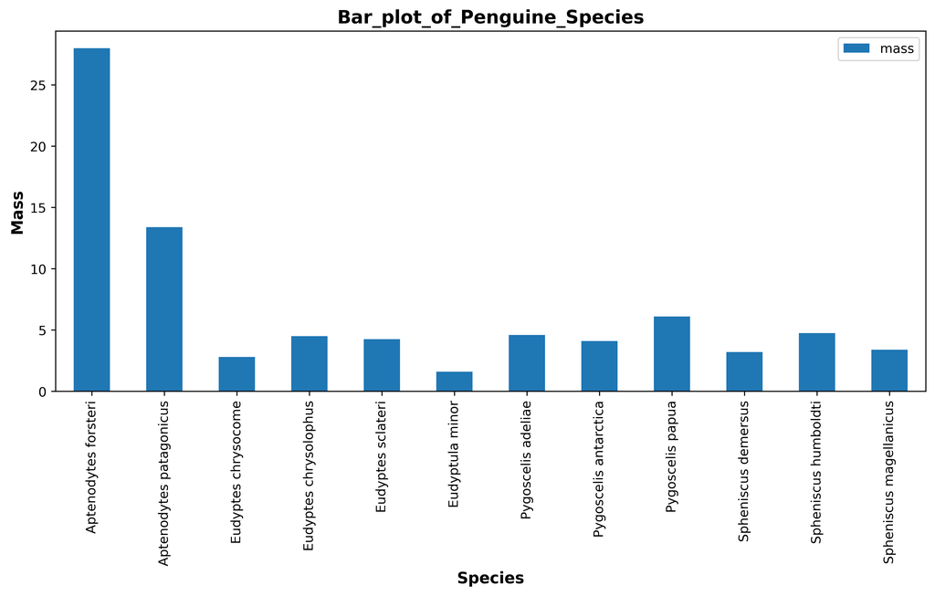

```python
# Plot for Q1 answer

penguins_df.plot(kind='bar', x='species', y='mass', title='Mass by species')
plt.title('Bar_plot_of_Penguine_Species', fontsize=14, fontweight='bold')
plt.xlabel('Species',fontsize=12, fontweight='bold')
plt.ylabel('Mass', fontsize=12, fontweight='bold')
plt.savefig('Bar_plot_of_Penguine_Species.png', format='png', dpi=400)
plt.show()
```

## Function 9

Plot a visualization of the molecular weight (y-axis) as a function of GC-content (x-axis).

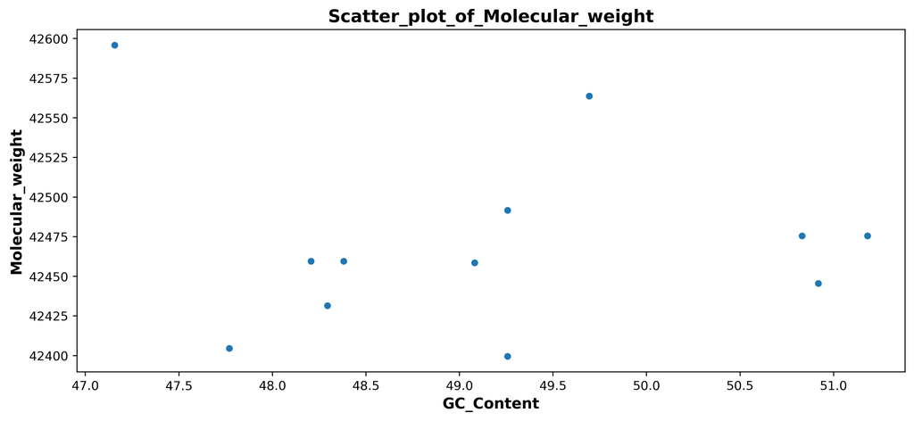

```python
# scatter plot for visuallizing molecular weight as a function of GC content

penguins_df.plot(kind='scatter', x="GC_content", y="molecular_weight", title= "Molecular weight as a function of GC content")
plt.title('Scatter_plot_of_Molecular_weight', fontsize=14, fontweight='bold')
plt.xlabel('GC_Content', fontsize=12, fontweight='bold')
plt.ylabel('Molecular_weight', fontsize=12, fontweight='bold')
plt.savefig('Scatter_plot_of_Molecular_weight.png', format='png', dpi=400)
plt.show()
```

## Function 10

Save the new DataFrame to a file called "penguins_mass_cytb.csv"

```python
# exports our data frame to a csv file ; index=False because we do not want to write row names

penguins_df.to_csv("penguins_mass_cytb.csv", index=False)
```

## Function 11: Bonus!

What else can we do with this dataset in Python?

Add functions or anything that might be interesting and fun. (optional)

```python
# I want to read my csv file so that I know it exported correctly so we can re-read that

My_penguin_file = pd.read_csv("penguins_mass_cytb.csv")

print(My_penguin_file)
```

```
                    species   mass  molecular_weight  GC_content
0      Aptenodytes forsteri  28.00        42459.6021   48.381452
1   Aptenodytes patagonicus  13.40        42563.7067   49.693788
2       Eudyptes chrysocome   2.80        42475.5753   51.181102
3     Eudyptes chrysolophus   4.50        42445.5493   50.918635
4         Eudyptes sclateri   4.25        42475.5753   50.831146
5           Eudyptula minor   1.60        42491.6408   49.256343
6        Pygoscelis adeliae   4.60        42458.6140   49.081365
7     Pygoscelis antarctica   4.10        42404.5423   47.769029
8          Pygoscelis papua   6.10        42595.8759   47.156605
9       Spheniscus demersus   3.20        42431.5490   48.293963
10     Spheniscus humboldti   4.75        42399.5520   49.256343
11  Spheniscus magellanicus   3.40        42459.6021   48.206474
```

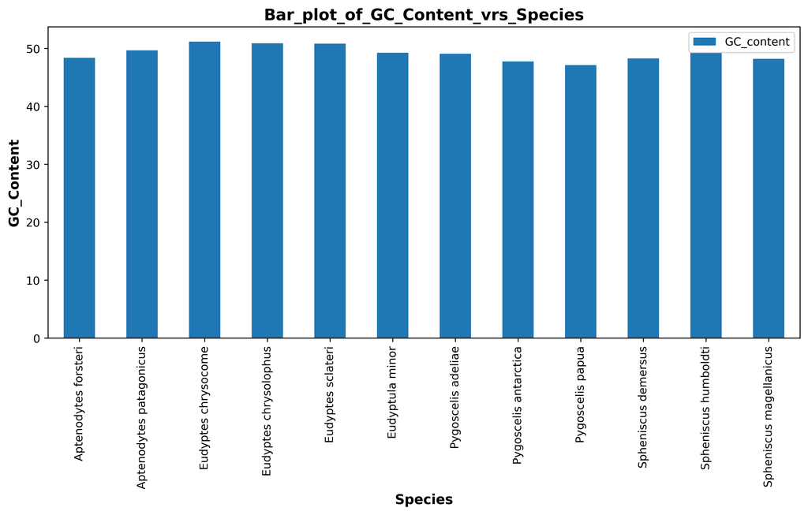

```python
# we can look at the GC content by species in a bar chart

penguins_df.plot(kind='bar', x='species', y='GC_content', title='GC content by species')
plt.title('Bar_plot_of_GC_Content_vrs_Species', fontsize=14, fontweight='bold')
plt.xlabel('Species', fontsize=12, fontweight='bold')
plt.ylabel('GC_Content', fontsize=12, fontweight='bold')
plt.savefig('Bar_plot_of_GC_Content_vrs_Species.png', format='png', dpi=400)
plt.show()
```

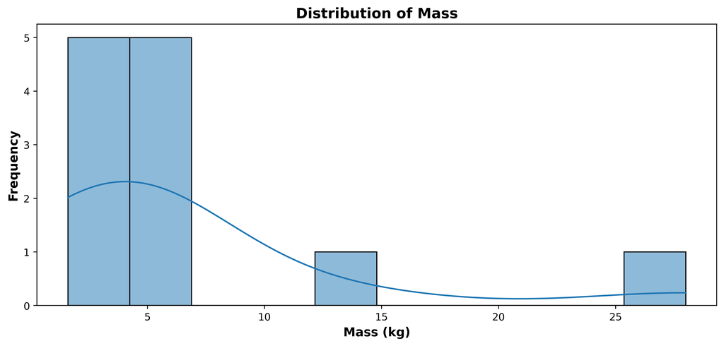

```python
# Plotting histogram for mass
sns.histplot(My_penguin_file['mass'], bins=10, kde=True)
plt.title('Distribution of Mass', fontsize=14, fontweight='bold')
plt.xlabel('Mass (kg)', fontsize=12, fontweight='bold')
plt.ylabel('Frequency', fontsize=12, fontweight='bold')
plt.savefig('Distribution of Mass.png', format='png', dpi=400)
plt.show()
```

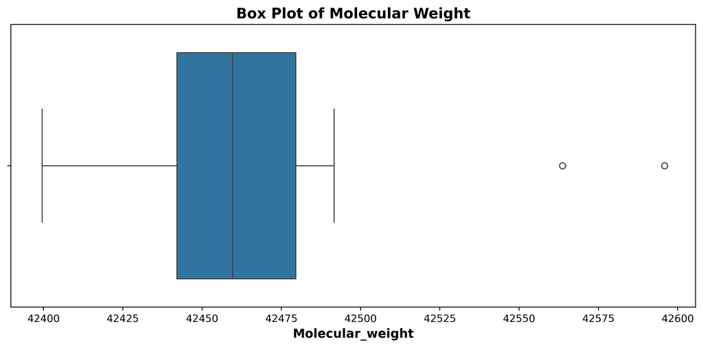

```python
# Box plot for molecular weight
sns.boxplot(x='molecular_weight', data=My_penguin_file)
plt.title('Box Plot of Molecular Weight', fontsize=14, fontweight='bold')
plt.xlabel('Molecular_weight', fontsize=12, fontweight='bold')
plt.savefig('Box Plot of Molecular Weight.png', format='png', dpi=400)
plt.show()
```

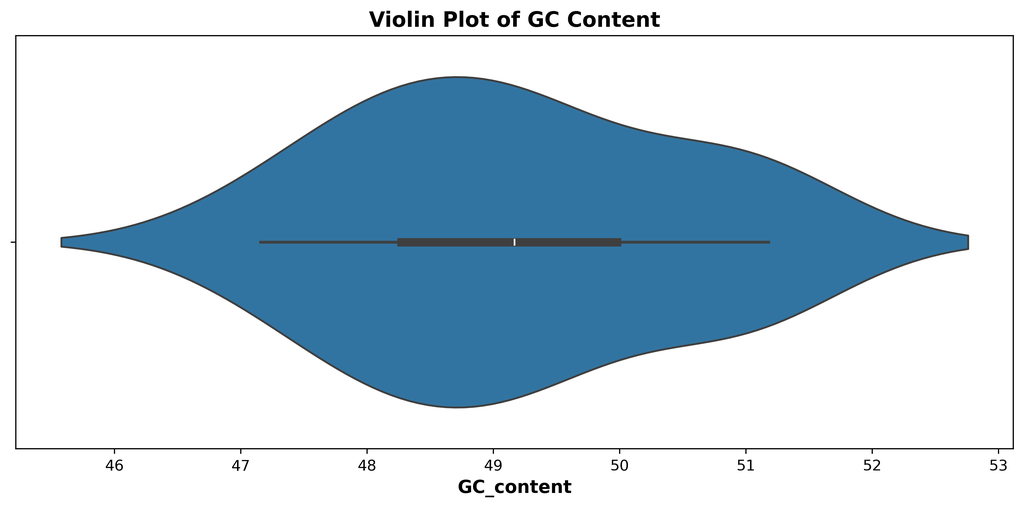

```python
# Violin plot for GC content
sns.violinplot(x='GC_content', data=My_penguin_file)
plt.title('Violin Plot of GC Content', fontsize=14, fontweight='bold')
plt.xlabel('GC_content', fontsize=12, fontweight='bold')
plt.savefig('Violin Plot of GC Content.png', format='png', dpi=400)
plt.show()
```

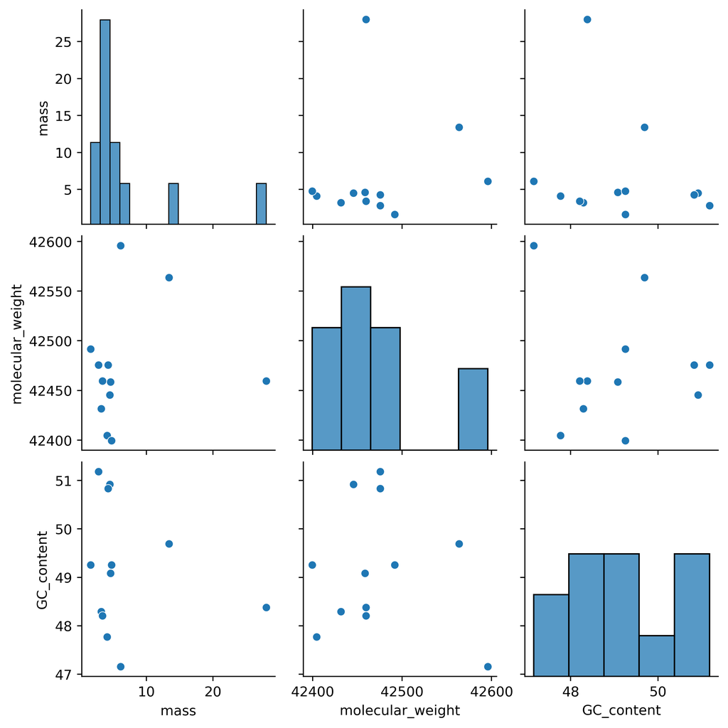

```python
# Pair plot of all numerical data
sns.pairplot(My_penguin_file)
plt.savefig('pairplot.png', format='png', dpi=400)
plt.show()
```

```
                    species   mass  molecular_weight  GC_content
10     Spheniscus humboldti   4.75        42399.5520   49.256343
7     Pygoscelis antarctica   4.10        42404.5423   47.769029
9       Spheniscus demersus   3.20        42431.5490   48.293963
3     Eudyptes chrysolophus   4.50        42445.5493   50.918635
6        Pygoscelis adeliae   4.60        42458.6140   49.081365
0      Aptenodytes forsteri  28.00        42459.6021   48.381452
11  Spheniscus magellanicus   3.40        42459.6021   48.206474
2       Eudyptes chrysocome   2.80        42475.5753   51.181102
4         Eudyptes sclateri   4.25        42475.5753   50.831146
5           Eudyptula minor   1.60        42491.6408   49.256343
1   Aptenodytes patagonicus  13.40        42563.7067   49.693788
8          Pygoscelis papua   6.10        42595.8759   47.156605
```

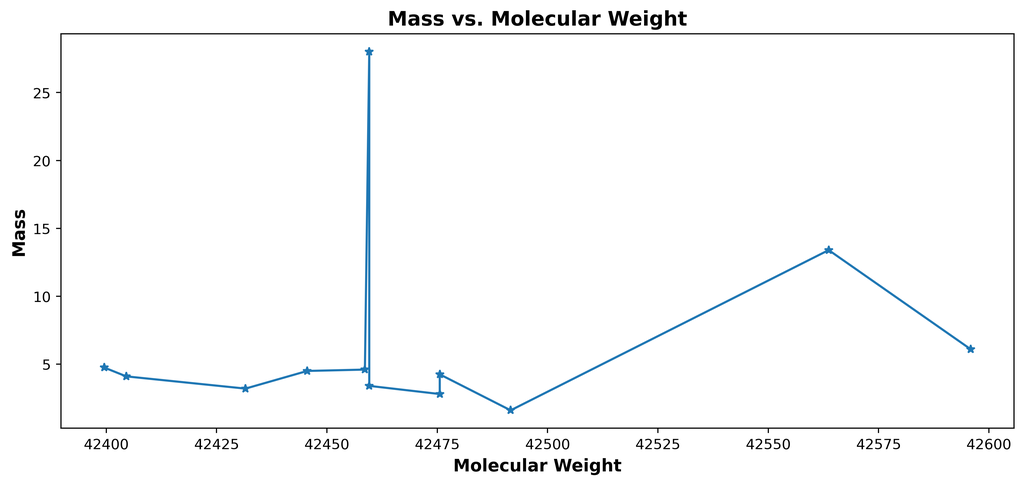

```python
# Line plot for mass sorted by molecular weight
# Just decided to play around by sorthing all the masses and molecular_weights
sorted_data = My_penguin_file.sort_values('molecular_weight')
print(sorted_data)
plt.plot(sorted_data['molecular_weight'], sorted_data['mass'], marker='*')
plt.title('Mass vs. Molecular Weight', fontsize=14, fontweight='bold')
plt.xlabel('Molecular Weight', fontsize=12, fontweight='bold')
plt.ylabel('Mass', fontsize=12, fontweight='bold')
plt.savefig('Mass vs. Sorted_Molecular Weight_.png', format='png', dpi=400)
plt.show()
```